# Mantenimiento y reparación de morsas

[figure not shown]

Fuente: Mercado Libre

## Introducción

La morsa es un elemento muy útil en un taller. En otros lugares también se las llama *“tornillos de banco”* y en inglés *“vice”* o *“bench vice”*.

Hay de distintos tamaños que se corresponden con un número siendo la `N° 1` la más chica. Una muy común es la `N° 3`.

Sus partes principales son:

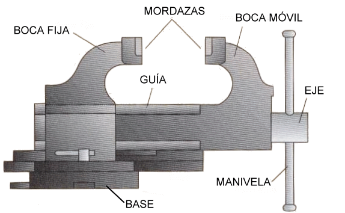

Fuente: Mercado Libre

## Como desarmar una morsa

Puede haber variaciones según la marca pero básicamente todas siguen los mismos principios.

A partir del minuto `1:48` hasta el `6:20` de este [video](https://www.youtube.com/watch?v=PCzG25f5Z2w) puedes ver como desarmar una morsa. Resumiendo hay que:

- Retirar la morsa del banco de trabajo
- Abrir al máximo la morza
- Sacar el perno (pin) retén de la tuerca
- Sacar la chaveta (traba) del resorte
- Sacar el tornillo y el resto

Luego para armarla se sigue un proceso inverso. La tarea más costosa es probablemente comprimir el resorte para poner la chaveta que lo traba.

## Mantenimiento y reparación

Según este [video](https://www.youtube.com/watch?v=iLYUtSw5PFM) los problemas más comunes son:

- **Chaveta (traba) del resorte rota** (Se manifiesta por ejemplo en que al empezar a girar el tornillo para abrir la morsa esta inicialmente no se mueve)
- **Tuerca rota**

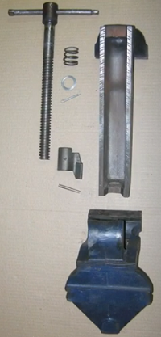

Fuente: Video de Youtube de Barbero SA. Despiece con todas las partes de una morsa.